# HomeWorkClear

```python
df.columns
```

```
Index(['Anket Yılı', '1.Düzey Bölgelendirme', '2.Düzey Bölgelendirme',
       'Hane Halkı Tipi Kodu', 'Oturulan Konut Tipi', 'Konut Mülkiyet',
       'O Konutta Oturmaya Veya Sahip Olmaya Başlanılan Yıl',
       'Aylık Ort.Konut Masrafı', 'Konut Oda Sayısı', 'Konut M^2',
       'Konut Isıtma Sistemi', 'Isınmak Içn En Fazla Kullanılan Yakıt Türü',
       'Konutta Banyo Veya Duşun Var Olma Durumu',
       'Konutta Tuvaletin Mevcut(Ev Içinde) Olma Durumu',
       'Konutta Bağımsız Mutfağın Mevcut Olma Durumu',
       'Konutta Borulu Su Sisteminin Mevcut Olma Durumu',
       'Konutta Sıcak Su Sisteminin(Güneş Enerjisi,Kombi,Şofben,Termal Su) Olma Durumu',
       'Hane Halkının Sabit Telefon Hattına Sahip Olma Durumu',
       'Hane Halkının Cep Telfonuna Sahip Olma Durumu',
       'Hane Halkının Renkli Tv Ye Sahip Olma Durumu',
       'Hanehalkının Pc Ye Sahip Olma Durumu',
       'Hanehalkının Internete Sahip Olma Durumu(Pc Ye Sahip Olanlardan)',
       'Hanehalkının Çamaşır Makinesi Olma Durumu', 'Buzdolabı Olma Durumu',
       'Bulaşık Maknesi Olma Durumu', 'Klima Olma Durumu',
       'Otomobil Olma Durumu(Iş Amaçlılar Hariç)',
       'Konutta Rutubet Olma Durumu', 'Konutta Izolasyon Olma Durumu',
       'Konutta Odaların Yeterli Işık Almama Durumu',
       'Konutta Komşulardan Veya Sokaktan Gürültü Probleminin Olup Olmadığı',
       'Konutun Kullanım Alanının Yeterli Olup Olmadığı',
       'Yaşanılan Çevrede Hava Kirliliği Durumu',
       'Suç Ve Şiddet Olaylarının Var Olma Durumu',
       'Son12 Ay Içinde Ev Kirasının Veya Konut Kredisinin Planlandığı Gibi Ödenememe Durumu',
       'Son12 Ay Içinde Elektrik,Su,Gaz Faturalarının Planlandığı Gibi Ödenememe Durumu(Borçla Ödeme Ödenmiş Kabul Edilecektir)',
       'Son12 Ay Içinde Taksit,Kredi Kartı Ve Diğer Borç Ödemelerinin Planlandığı Gibi Gitmeme Durumu',
       'Hane Aylık Geliriyle Hane Gençinebilme Durumu',
       'Hanenin Geçinebilmek Için Min. Ihtıyacı Tl',
       'Konut Harcamalarının Haneye Getirdiği Yük Tipi',
       'Konut Dışı Borç Ve Taksit Ödemelerinin Haneye Getirdiği Yğk Tipi',
       'Hane 1 Hafta Tatil Masrafını Karşılayabilir Mi',
       'Hane 2 Günde Bir Et Yemeyi Karşılayabilir Mi',
       'Hane Beklenmedik Mecburi 452Tl Haycamayı Ödeyebilme Durumu',
       'Hane Ev Isınmasını Ekonomik Sağlayabiliyor Mu',
       '2. El Dahil, Mobilyalarınız Eskidiğinde Yeniler Misiniz',
       'Toplam Hane Kullanılabilir Geliri', 'Konut Kalitesi',
       'Hane Maddi Durumu', 'Hane Yaşam Konforu', 'Yaşanılan Bölge Konforu'],
      dtype='object')
```

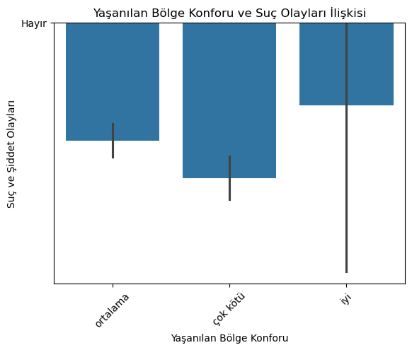

```
Suç olayları azaldıkça bölge konforu artıyor
```

```python
import seaborn as sns
import matplotlib.pyplot as plt

# Yaşanılan Bölge Konforu vs Suç Ve Şiddet Olaylarının Var Olma Durumu için çubuk grafik (Bar Plot)
sns.barplot(
    x='Yaşanılan Bölge Konforu',
    y='Suç Ve Şiddet Olaylarının Var Olma Durumu',
    data=korelasyon4
)

# Başlık ve etiketler
plt.title('Yaşanılan Bölge Konforu ve Suç Olayları İlişkisi')
plt.xlabel('Yaşanılan Bölge Konforu')
plt.ylabel('Suç ve Şiddet Olayları')

# Grafik gösterimi
plt.xticks(rotation=45)  # X eksenindeki etiketleri döndürerek daha okunabilir hale getirebiliriz
plt.show()
print("Suç olayları azaldıkça bölge konforu artıyor")
```

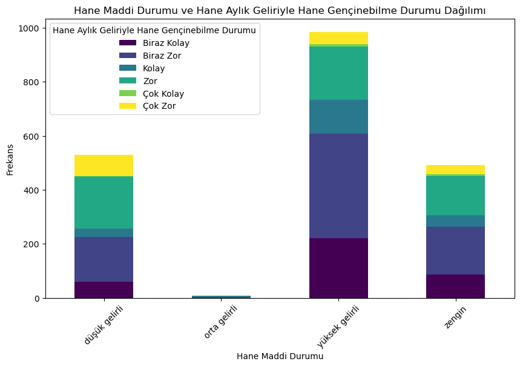

```python
import matplotlib.pyplot as plt

# Veri: 'Hane Maddi Durumu' ve 'Hane Aylık Geliriyle Hane Gençinebilme Durumu'na göre gruplama
grouped_data = korelasyon4.groupby(['Hane Maddi Durumu', 'Hane Aylık Geliriyle Hane Gençinebilme Durumu']).size().unstack()

# Yığılmış çubuk grafik (stacked bar chart)
grouped_data.plot(kind='bar', stacked=True, figsize=(10, 6), cmap='viridis')

plt.title('Hane Maddi Durumu ve Hane Aylık Geliriyle Hane Gençinebilme Durumu Dağılımı')
plt.xlabel('Hane Maddi Durumu')
plt.ylabel('Frekans')
plt.xticks(rotation=45)
plt.show()
```

## BEN BİYERDEN EV ALMAYI DÜŞÜNÜYORUM NEREDEN ALMALIYIM?

**Suç Ve Şiddet Olaylarının Var Olma Durumu' , 'Yaşanılan Çevrede Hava Kirliliği Durumu' , 'Konutun Kullanım Alanının Yeterli Olup Olmadığı', 'Konutta Komşulardan Veya Sokaktan Gürültü Probleminin Olup Olmadığı',**

**=== yaşanılan bölge konforu**

```python
df['Suç Ve Şiddet Olaylarının Var Olma Durumu'].isnull().sum()
```

```
0
```

```python
df['Yaşanılan Çevrede Hava Kirliliği Durumu'].isnull().sum()
```

```
0
```

```python
df['Konutun Kullanım Alanının Yeterli Olup Olmadığı'].isnull().sum()
```

```
0
```

```python
df['Konutta Komşulardan Veya Sokaktan Gürültü Probleminin Olup Olmadığı'].isnull().sum()
```

```
0
```

```python
df["Yaşanılan Bölge Konforu"].value_counts()
```

```
Yaşanılan Bölge Konforu
ortalama    11617
çok kötü    10085
iyi          1038
Name: count, dtype: int64
```

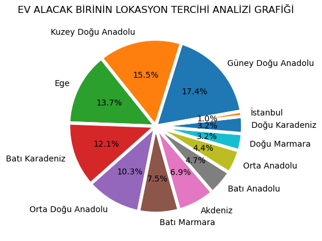

```
yaşamak için Batı Karedeniz seçtim ben
```

```python
satınalım = df[(df['Yaşanılan Bölge Konforu'].isin(['iyi']))]

satınalım["1.Düzey Bölgelendirme"].value_counts().plot.pie(
    autopct='%1.1f%%',  # Her bir dilimin yüzdesini gösterir
    wedgeprops={'linewidth': 4, 'edgecolor': 'white'},  # Dilimler arasında boşluk bırakır
    startangle=10  # Grafiği 90 derece döndürerek başlatır (isteğe bağlı)
)
plt.ylabel('')  # Y-eksenindeki etiketi kaldırır
plt.title("EV ALACAK BİRİNİN LOKASYON TERCİHİ ANALİZİ GRAFİĞİ")
plt.show()
print("yaşamak için Batı Karedeniz seçtim ben")
```

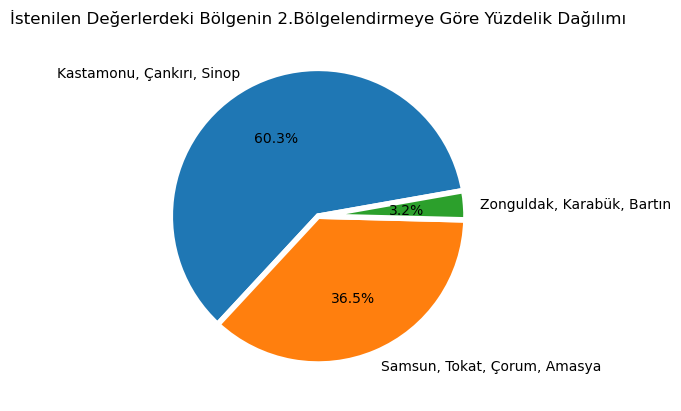

```
Sinopta yaşayacağım
```

```python
satınalım = df[(df['Yaşanılan Bölge Konforu'].isin(['iyi'])) &
               (df['1.Düzey Bölgelendirme'] == 'Batı Karadeniz')]

satınalım["2.Düzey Bölgelendirme"].value_counts().plot.pie(
    autopct='%1.1f%%',  # Her bir dilimin yüzdesini gösterir
    wedgeprops={'linewidth': 4, 'edgecolor': 'white'},  # Dilimler arasında boşluk bırakır
    startangle=10  # Grafiği 90 derece döndürerek başlatır (isteğe bağlı)
)
plt.ylabel('')  # Y-eksenindeki etiketi kaldırır
plt.title("İstenilen Değerlerdeki Bölgenin 2.Bölgelendirmeye Göre Yüzdelik Dağılımı")
plt.show()
print("Sinopta yaşayacağım")
```

## Tanımlar ve Ders Notları

****İŞLEM SIRASI****

1-) birbirine yakın olan verileri kümele (clustring analysis) 2-)Korelasyon analizi ile kümelediğin verileri karşılaştır aralarındaki ilişkiyi anlamlandır (Correlations steps) -->korelasyon sonucu çıkan yeni verilerle yeni sütun oluşturup onuda ana veri tablosuna yazdırmam lazım. Apply() fonku kullanıcam 3-)Group By ile verileri anlamlı bir şekilde gruplamam ve grafik çizmeden önce gözlemlemem lazım gruplama içerisinde sıralama yaparken index'e göre sort_index() --- elde edilen değerlere göre sıralama yaparken sort_values() kullnaılırlar 4-)bunlardan sonra profiling yap 5-)en son grafik çizdir

****(high correlations) yüksek korelasyona sahip Oluşturduğum Kümeler(clustring analysis):****

1-)1.Düzey Bölgelendirme - 2.Düzey Bölgelendirme 2-)2.El Dahil, Mobilyalarınız Eskidiğinde Yeniler Misiniz - Hane 1 Hafta Tatil Masrafını Karşılayabilir Mi - Hane 2 Günde Bir Et Yemeyi Karşılayabilir Mi - Hane Beklenmedik Mecburi 452Tl Haycamayı Ödeyebilme Durumu 3-)Hanehalkının Internete Sahip Olma Durumu(Pc Ye Sahip Olanlardan) - Hanehalkının Pc Ye Sahip Olma Durumu 4-)Isınmak Içn En Fazla Kullanılan Yakıt Türü - Konut Isıtma Sistemi 5-)Konut Dışı Borç Ve Taksit Ödemelerinin Haneye Getirdiği Yğk Tipi - Son12 Ay Içinde Taksit,Kredi Kartı Ve Diğer Borç Ödemelerinin Planlandığı Gibi Gitmeme Durumu 6-)Konut M^2 - Konut Oda Sayısı 7-)Konutta Banyo Veya Duşun Var Olma Durumu - Konutta Tuvaletin Mevcut(Ev Içinde) Olma Durumu 8-)Konutta Rutubet Olma Durumu - Konutta Izolasyon Olma Durumu - Konut Odaların Işık Almama Durumu

****Korelasyon Türleri:**** Pozitif Korelasyon: İki değişken aynı yönde değişir. Örneğin, sıcaklık ile dondurma satışları arasında pozitif bir korelasyon olabilir.

Negatif Korelasyon: İki değişken zıt yönde değişir. Örneğin, araba hızı ile yakıt verimliliği arasında negatif bir korelasyon olabilir.

Korelasyon Yok: İki değişken arasında anlamlı bir ilişki yoktur. Örneğin, bir kişinin boyu ile telefon markası arasında korelasyon olmayabilir.

****BELİRLENEN KÜMELER ARASINDA YAPILAN KORELASYON ANALİZİNDEN SONRA ÇIKAN SONUÇLAR**** (bu sonuçlar ekteki iki dosyada verilmektedir grafikleri ile)

****IMBALANCE(dağılımda dengesizlik içeren ilişkiler)=**** Konutta Banyo Veya Duşun Var Olma Durumu is highly imbalanced (79.1%) Imbalance Konutta Tuvaletin Mevcut(Ev Içinde) Olma Durumu is highly imbalanced (64.4%) Imbalance Konutta Bağımsız Mutfağın Mevcut Olma Durumu is highly imbalanced (83.1%) Imbalance Konutta Borulu Su Sisteminin Mevcut Olma Durumu is highly imbalanced (88.7%) Imbalance Hane Halkının Cep Telfonuna Sahip Olma Durumu is highly imbalanced (80.0%) Imbalance Hane Halkının Renkli Tv Ye Sahip Olma Durumu is highly imbalanced (89.8%) Imbalance Hanehalkının Çamaşır Makinesi Olma Durumu is highly imbalanced (81.1%) Imbalance Buzdolabı Olma Durumu is highly imbalanced (91.6%) Imbalance Suç Ve Şiddet Olaylarının Var Olma Durumu is highly imbalanced (57.2%)

****MISSING(eksik veri içeren ilişkiler)=**** 2.Düzey Bölgelendirme has 709 (3.1%) missing values

****Skewing (Çarpık veri içeren ilişkiler):**** Hanenin Geçinebilmek Için Min. Ihtıyacı Tl is highly skewed (γ1 = 46.66913529)

****TERİMLERİN KISACA AÇIKLAMALARI****

Veri işleme ve makine öğrenmesi bağlamında ****imbalance (dengesizlik)****, özellikle sınıflandırma problemlerinde, verilerdeki sınıfların eşit olmayan dağılımını ifade eder. Yani, bir veri setindeki bazı sınıflar diğerlerine göre çok daha fazla örneğe sahip olduğunda, bu duruma sınıf dengesizliği (class imbalance) denir.** **Çözüm Yöntemleri:**** Veri Dengeleme (Resampling): Oversampling: Azınlık sınıfındaki örnekleri çoğaltmak (örneğin, SMOTE tekniği). Undersampling: Çoğunluk sınıfındaki örneklerin sayısını azaltmak. Ağırlıklı Kaybı Fonksiyonları: Azınlık sınıfına daha fazla ağırlık vererek modelin ona daha fazla dikkat etmesini sağlamak. Farklı Algoritmalar: Sınıf dengesizliğine dayanıklı algoritmalar kullanmak (örneğin, XGBoost gibi modeller). Farklı Değerlendirme Metrikleri: Sadece doğruluk (accuracy) yerine, F1 skoru, precision, recall gibi metrikler kullanmak, çünkü doğruluk genellikle dengesiz veri setlerinde yanıltıcı olabilir. Sınıf dengesizliği, doğru modelleme ve değerlendirme yöntemleri ile yönetilmesi gereken önemli bir sorundur.

****Missing (Eksik Veri):**** Eksik veri (missing data), veri setindeki bazı gözlemlerin (satırların veya sütunların) tamamlanmamış, hatalı veya kayıp olduğu durumu ifade eder. Yani, veri setinde bir değişkenin veya gözlemin değeri mevcut değildir.

Eksik Veri Türleri: MCAR (Missing Completely at Random): Eksik veriler tamamen rastlantısaldır ve verinin geri kalan kısmından bağımsızdır. Örneğin, bir anketin yanıtları rastgele kaybolmuş olabilir. MAR (Missing at Random): Eksik veriler, gözlemci faktörlerden veya diğer gözlemlerden etkilenebilir, ancak eksik olan veriyle doğrudan ilişkili değildir. Örneğin, belirli bir gelir aralığındaki kişiler ankete daha az yanıt verebilir. MNAR (Missing Not at Random): Eksik veriler, eksik olan verinin kendisiyle ilgilidir. Örneğin, düşük gelirli kişilerin gelir hakkında bilgi vermemesi durumunda eksik veriler gelir ile doğrudan ilişkilidir.

Eksik Veriyi Ele Alma Yöntemleri: Silme (Deletion): Eksik veriye sahip gözlemler ya da değişkenler tamamen çıkarılabilir. İmmülasyon (Imputation): Eksik veriler, ortalama, medyan, mod gibi istatistiksel tahminler veya daha gelişmiş yöntemlerle tamamlanabilir. Modelleme: Bazı makine öğrenmesi algoritmaları eksik verileri göz önünde bulundurarak tahmin yapabilir.

*****Skewing (Çarpıklık):***** Çarpıklık (skewness), bir veri dağılımının simetrik olup olmadığını ve varsa ne kadar asimetrik olduğunu ölçen bir istatistiksel terimdir. Çarpıklık, dağılımın sağa veya sola kayıp kaymadığını gösterir.

Çarpıklık Türleri:

Pozitif Çarpıklık (Right Skewed veya Positively Skewed): Dağılımın sağ tarafı (büyük değerler) daha uzun bir kuyruğa sahiptir. Yani, çoğunlukla düşük değerlere sahiptir ve birkaç yüksek değer (outlier) sağda yoğunlaşır. Bu, örneğin gelir dağılımında yaygın olabilir; çoğu kişi düşük gelire sahipken, birkaç kişi çok yüksek gelire sahiptir.

Çarpıklık değeri pozitif olur. Negatif Çarpıklık (Left Skewed veya Negatively Skewed): Dağılımın sol tarafı (küçük değerler) daha uzun bir kuyruğa sahiptir. Yani, çoğunlukla yüksek değerlere sahiptir ve birkaç düşük değer (outlier) solda yoğunlaşır.

Çarpıklık değeri negatif olur. Simetrik Dağılım: Verilerin çoğunluğu ortada yoğunlaşmış ve her iki tarafta da benzer bir dağılım gösteriyorsa, bu durumda çarpıklık değeri sıfır olur. Çarpıklık ve Veri Analizi: Çarpıklık, veri setinin normal dağılımdan ne kadar saptığını gösterir. Pozitif veya negatif çarpıklık, verinin dönüşümünü (log dönüşümü gibi bu dönüşüm aşırı yüksek verileri istenilen aralığa indirir) gerektirebilir, özellikle makine öğrenmesi ve istatistiksel analizlerde daha doğru sonuçlar elde etmek için.

## 9-)KENDİ ANALİZLERİM DIŞINDA KÜTÜPHANE ANALİZLERİ

## 2 FARKLI ANALİZ DOSYASI ELDESİ (İLETTİĞİM DOSYADAKİ EKTEDİRLER)

```python
for i in df.columns:
    print(df[i].value_counts())
    print("---------------------------------------------")    #her kolondaki farklı değerlerden kaçar tane olduğuna baktık
                                                              #bu farklı değerler value_counts() ile gözükür ama biz sadece farklı değerlerin adlarına
                                                              #erişmek istiyorsak unique() fonkunu kullanabilirdik
```

```
Anket Yılı
2014    22740
Name: count, dtype: int64
---------------------------------------------
1.Düzey Bölgelendirme
Ege                    3191
Akdeniz                2771
Güney Doğu Anadolu     2146
Batı Anadolu           2104
Batı Karadeniz         2099
İstanbul               2015
Doğu Marmara           2002
Batı Marmara           1518
Orta Anadolu           1507
Orta Doğu Anadolu      1420
Kuzey Doğu Anadolu     1258
Doğu Karadeniz          709
Name: count, dtype: int64
---------------------------------------------
2.Düzey Bölgelendirme
İstanbul                                         2015
Ankara                                           1269
İzmir                                            1175
Bursa, Eskişehir, Bilecik                        1090
Manisa, Afyon, Kütahya, Uşak                     1057
Adana, Mersin                                    1037
Aydın, Denizli, Muğla                             959
Kocaeli, Sakarya, Düzce, Bolu, Yalova             912
Hatay, Kahramanmaraş, Osmaniye                    891
Antalya, Isparta, Burdur                          843
Konya, Karaman                                    835
Kayseri, Sivas, Yozgat                            777
Balıkesir, Çanakkale                              762
Tekirdağ, Edirne, Kırklareli                      756
Malatya, Elazığ, Bingöl, Tunceli                  745
Samsun, Tokat, Çorum, Amasya                      737
Kırıkkale, Aksaray, Niğde, Nevşehir, Kırşehir     730
Mardin, Batman, Şırnak, Siirt                     720
Gaziantep, Adıyaman, Kilis                        719
Şanlıurfa, Diyarbakır                             707
```

[output cut: 331 more lines]

```
orta gelirli        927
Name: count, dtype: int64
---------------------------------------------
Hane Yaşam Konforu
orta         20217
konforlu      1485
orta altı     1038
Name: count, dtype: int64
---------------------------------------------
Yaşanılan Bölge Konforu
ortalama    11617
çok kötü    10085
iyi          1038
Name: count, dtype: int64
---------------------------------------------
```

```python
df
```

|  | Anket Yılı | 1.Düzey Bölgelendirme | 2.Düzey Bölgelendirme | Hane Halkı Tipi Kodu | Oturulan Konut Tipi | Konut Mülkiyet | O Konutta Oturmaya Veya Sahip Olmaya Başlanılan Yıl | Aylık Ort.Konut Masrafı | Konut Oda Sayısı | Konut M^2 | ... | Hane 1 Hafta Tatil Masrafını Karşılayabilir Mi | Hane 2 Günde Bir Et Yemeyi Karşılayabilir Mi | Hane Beklenmedik Mecburi 452Tl Haycamayı Ödeyebilme Durumu | Hane Ev Isınmasını Ekonomik Sağlayabiliyor Mu | 2. El Dahil, Mobilyalarınız Eskidiğinde Yeniler Misiniz | Toplam Hane Kullanılabilir Geliri | Konut Kalitesi | Hane Maddi Durumu | Hane Yaşam Konforu | Yaşanılan Bölge Konforu |
| --- | --- | --- | --- | --- | --- | --- | --- | --- | --- | --- | --- | --- | --- | --- | --- | --- | --- | --- | --- | --- | --- |
| 0 | 2014 | İstanbul | İstanbul | Tek kişilik hanehalkı | Apartman (10 daireden fazla) | Kiracı | 2011 | 2997.97714 | 3 | 90 | ... | Evet | Evet | Evet | Evet | Evet | 57667.60000 | çok kötü | yüksek gelirli | orta | ortalama |
| 1 | 2014 | İstanbul | İstanbul | Tek kişilik hanehalkı | Apartman (10 daireden fazla) | Kiracı | 2011 | 15650.00000 | 4 | 120 | ... | Evet | Evet | Evet | Evet | Hayır, maddi yetersizlik | 37391.40000 | çok kötü | düşük gelirli | orta | çok kötü |
| 2 | 2014 | İstanbul | İstanbul | Bağımlı çocuk olmayan hanehalkları 6+7+8 | Apartman (10 daireden fazla) | Lojman | 2011 | 6750.00000 | 4 | 120 | ... | Evet | Evet | Evet | Evet | Evet | 93366.00000 | çok kötü | yüksek gelirli | orta | ortalama |
| 3 | 2014 | İstanbul | İstanbul | Bağımlı çocuk olmayan iki yetişkinli yetişkinl... | Apartman (10 daireden az) | Kiracı | 2013 | 2997.97714 | 3 | 100 | ... | Hayır | Evet | Evet | Evet | Hyır, diğer nedenler | 32100.00000 | çok kötü | yüksek gelirli | orta | ortalama |
| 4 | 2014 | İstanbul | İstanbul | Bağımlı çocuk olmayan iki yetişkinli yetişkinl... | Apartman (10 daireden fazla) | Ev Sahibi | 2009 | 2997.97714 | 3 | 70 | ... | Hayır | Evet | Evet | Evet | Hyır, diğer nedenler | 30533.57274 | çok kötü | yüksek gelirli | orta | ortalama |
| ... | ... | ... | ... | ... | ... | ... | ... | ... | ... | ... | ... | ... | ... | ... | ... | ... | ... | ... | ... | ... | ... |
| 22735 | 2014 | Güney Doğu Anadolu | Mardin, Batman, Şırnak, Siirt | bilinmiyor | Müstakil Konut | Ev Sahibi | 2006 | 2997.97714 | 3 | 100 | ... | Hayır | Evet | Evet | Hayır | Hyır, diğer nedenler | 30533.57274 | çok kötü | yüksek gelirli | orta | ortalama |
| 22736 | 2014 | Güney Doğu Anadolu | Mardin, Batman, Şırnak, Siirt | bilinmiyor | Müstakil Konut | Ev Sahibi | 1988 | 450.00000 | 3 | 115 | ... | Hayır | Hayır | Evet | Hayır | Hyır, diğer nedenler | 30533.57274 | çok kötü | zengin | orta | çok kötü |
| 22737 | 2014 | Güney Doğu Anadolu | Mardin, Batman, Şırnak, Siirt | bilinmiyor | Müstakil Konut | Ev Sahibi | 1990 | 750.00000 | 2 | 80 | ... | Hayır | Hayır | Evet | Hayır | Hayır, maddi yetersizlik | 30533.57274 | çok kötü | zengin | orta | çok kötü |
| 22738 | 2014 | Güney Doğu Anadolu | Mardin, Batman, Şırnak, Siirt | bilinmiyor | Müstakil Konut | Ev Sahibi | 1990 | 750.00000 | 3 | 120 | ... | Hayır | Hayır | Evet | Hayır | Hayır, maddi yetersizlik | 30533.57274 | çok kötü | zengin | orta | çok kötü |
| 22739 | 2014 | Güney Doğu Anadolu | Mardin, Batman, Şırnak, Siirt | bilinmiyor | Müstakil Konut | Diğer(herhangi bir kira ödemeyen) | 2007 | 2997.97714 | 2 | 60 | ... | Hayır | Evet | Evet | Evet | Hayır, maddi yetersizlik | 30533.57274 | çok kötü | düşük gelirli | orta | çok kötü |

22740 rows × 51 columns